# Data Types & Visualizations — Slideshow

Examples of: 1D Time Series, 2D Scalar Field, 3D Scalar Field, 2D Vector Field, 3D Shape, Graph (not tree). Images are generated locally and displayed via `IPython.display.Image`.

```python
from IPython.display import display, Image
print('Ready to display images…')
```

```
Ready to display images…
```

## 1. 1D Time Series

A single variable observed over time. Here the data are `x(t)` sampled from a sum of sine waves; the plot shows amplitude versus time (1D function of t).

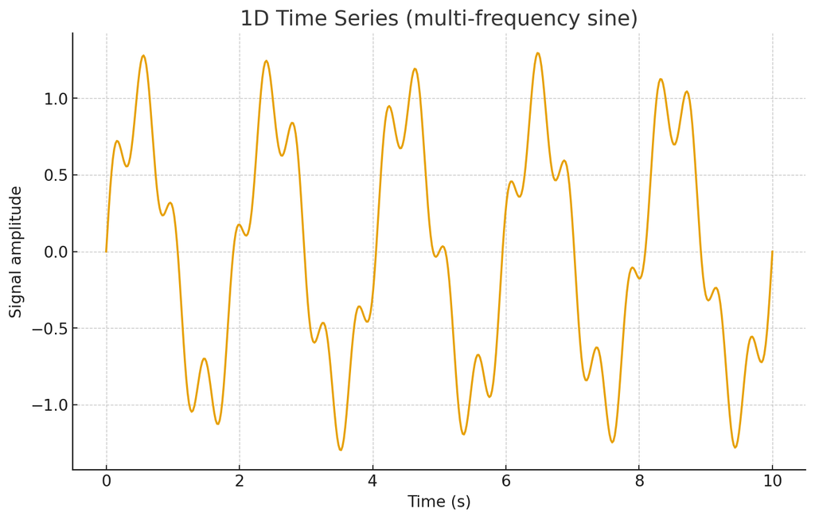

```python
from IPython.display import display, Image
display(Image(filename=r'/mnt/data/vis_slides_images/time_series.png'))
```

## 2. 2D Scalar Field

A scalar value defined on a 2D grid. We render `f(x, y)` as a heatmap where color encodes the scalar magnitude at each (x, y).

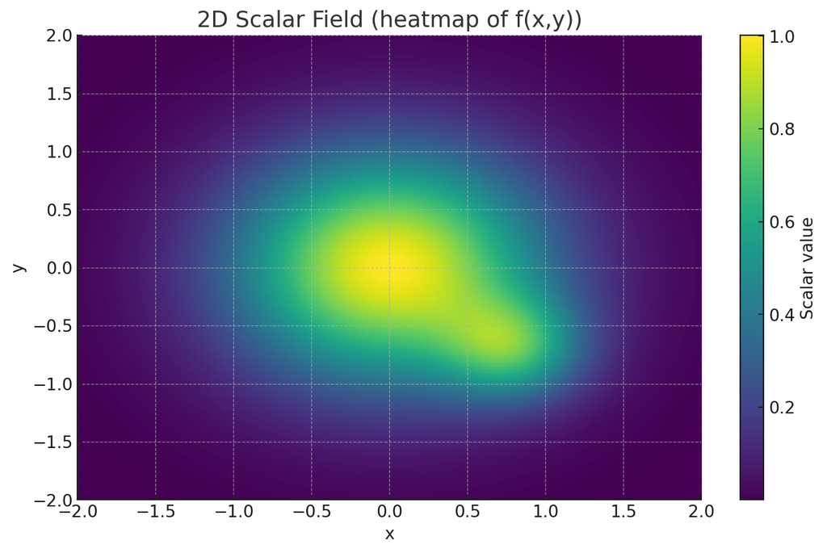

```python
from IPython.display import display, Image
display(Image(filename=r'/mnt/data/vis_slides_images/scalar2d.png'))
```

## 3. 3D Scalar Field

A scalar value defined over 3D space. We visualize it by three orthogonal **slices** (XY, XZ, YZ), each a 2D slice through the 3D volume.

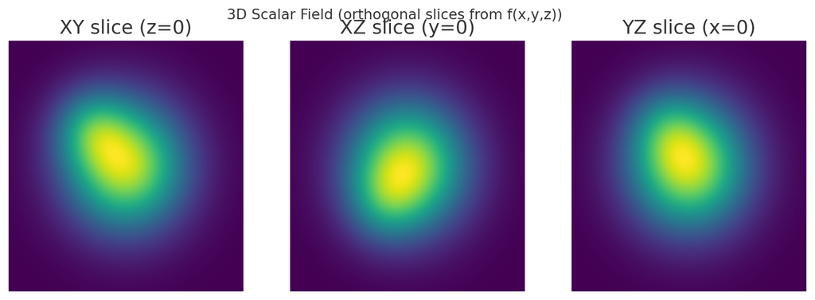

```python
from IPython.display import display, Image
display(Image(filename=r'/mnt/data/vis_slides_images/scalar3d_slices.png'))
```

## 4. 2D Vector Field

A vector assigned to each 2D location. We show the rotational field `(u,v)=(-y, x)` with arrows whose direction and length encode the local vector.

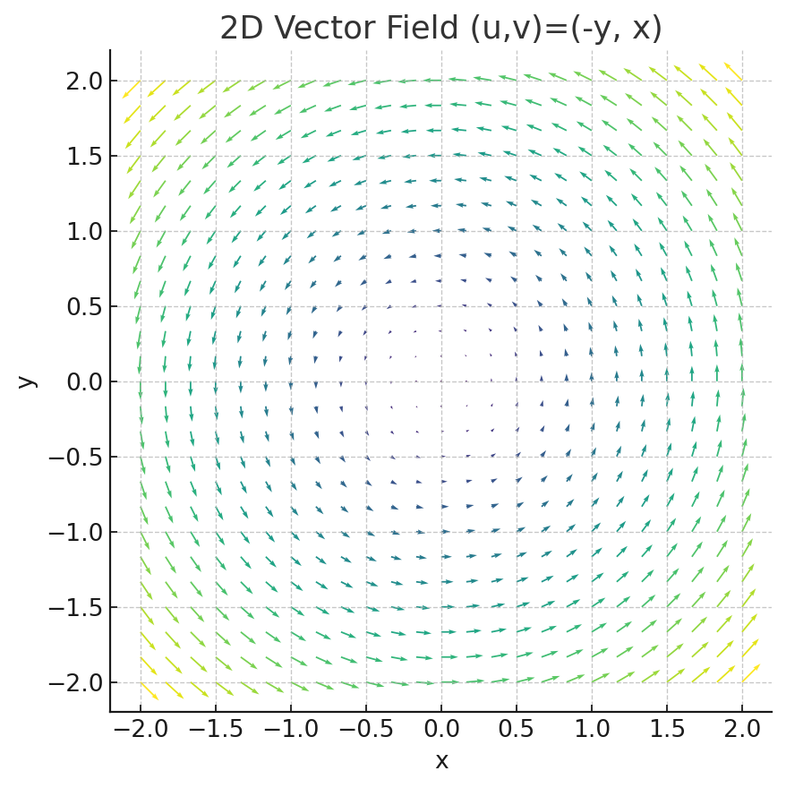

```python
from IPython.display import display, Image
display(Image(filename=r'/mnt/data/vis_slides_images/vector2d.png'))
```

## 5. 3D Shape

A 2D surface embedded in 3D (a geometric object), here a **torus** defined parametrically. It represents shape/geometry rather than a scalar field.

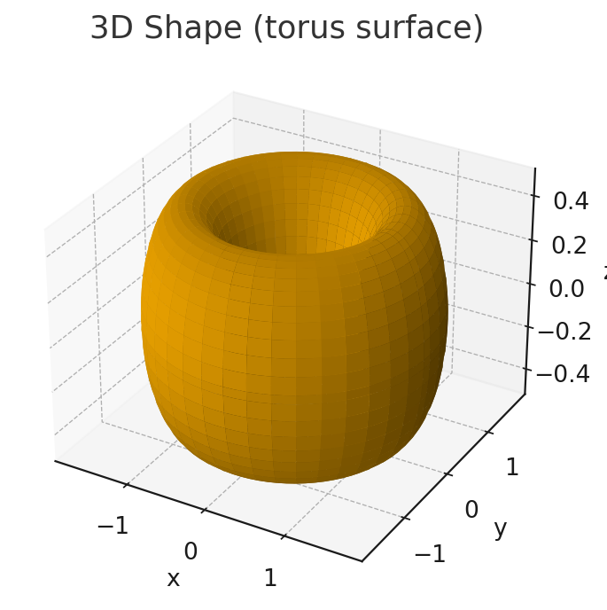

```python
from IPython.display import display, Image
display(Image(filename=r'/mnt/data/vis_slides_images/shape3d.png'))
```

## 6. Graph (not tree)

A set of nodes and edges containing at least one **cycle** (so it is not a tree). The cycle 1–2–3–4–1 is clearly visible.

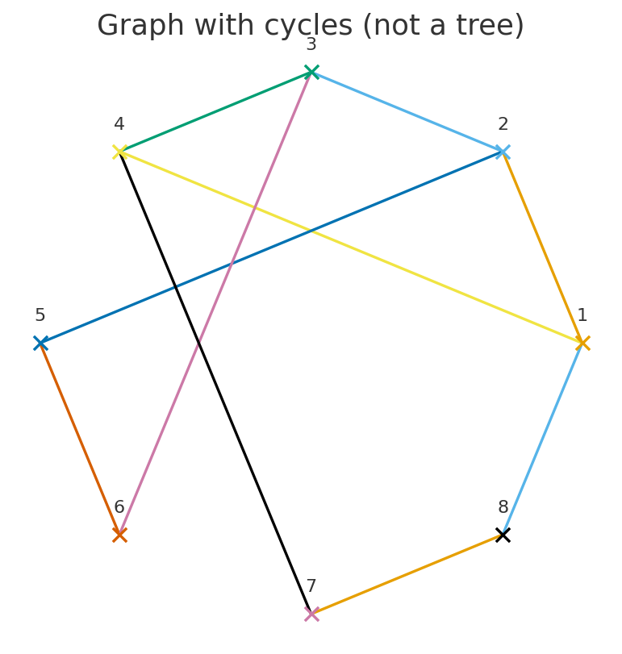

```python
from IPython.display import display, Image
display(Image(filename=r'/mnt/data/vis_slides_images/graph_not_tree.png'))
```